# WilloughbyHW3

```r
# Load data library
library(faraway)
```

# Problem 1

Using the dataset `gala` discussed in Chapter 2, consider a regression model with `Endemics` (Y) as the response and `Area` ($X_1$), `Elevation` ($X_2$), `Nearest` ($X_3$), `Scruz` ($X_4$), and `Adjacent` ($X_5$) as predictors.

```r
# help(gala)
data(gala)
head(gala)
```

```
##              Species Endemics  Area Elevation Nearest Scruz Adjacent
## Baltra            58       23 25.09       346     0.6   0.6     1.84
## Bartolome         31       21  1.24       109     0.6  26.3   572.33
## Caldwell           3        3  0.21       114     2.8  58.7     0.78
## Champion          25        9  0.10        46     1.9  47.4     0.18
## Coamano            2        1  0.05        77     1.9   1.9   903.82
## Daphne.Major      18       11  0.34       119     8.0   8.0     1.84
```

```r
# fit full model
fit1 <- lm(Endemics ~ Area + Elevation + Nearest + Scruz + Adjacent, gala)
print(summary(fit1))
```

```
##
## Call:
## lm(formula = Endemics ~ Area + Elevation + Nearest + Scruz +
##     Adjacent, data = gala)
##
## Residuals:
##     Min      1Q  Median      3Q     Max
## -24.201  -7.941  -1.637   6.086  25.376
##
## Coefficients:
##              Estimate Std. Error t value Pr(>|t|)
## (Intercept)  5.099665   3.859507   1.321   0.1989
## Area        -0.008466   0.004518  -1.874   0.0732 .
## Elevation    0.083530   0.010813   7.725 5.83e-08 ***
## Nearest      0.025173   0.212405   0.119   0.9066
## Scruz       -0.056623   0.043403  -1.305   0.2044
## Adjacent    -0.017438   0.003567  -4.889 5.50e-05 ***
## ---
## Signif. codes:  0 '***' 0.001 '**' 0.01 '*' 0.05 '.' 0.1 ' ' 1
##
## Residual standard error: 12.29 on 24 degrees of freedom
## Multiple R-squared:  0.8328, Adjusted R-squared:  0.7979
## F-statistic:  23.9 on 5 and 24 DF,  p-value: 1.35e-08
```

### Problem 1a

For the regression model above, what are the t-test results (i.e. test statistic value, p-value, and your conclusion) for testing $H_o: \beta_{Nearest} = 0 \text{ with } \alpha = 0.05.$ Find the $95\%$ confidence intervals for $\beta_{Nearest}$.

The test statistic is given by $t_{24} \approx 0.119$. The two-sided p-value is $P(|t_{24}| \ge 0.119) \approx 0.91.$ This means that, under the null hypothesis $H_0: \beta_{\text{Nearest}} = 0$, observing a test statistic as (or more) extreme as $t_{24} = 0.119$ is very likely. Since $p = 0.91 \gg \alpha = 0.05$, we fail to reject $H_0$. In other words, the data provide no evidence for a (nonzero) linear effect of `Nearest` on `Endemic`. The 95% confidence interval for $\beta_{\text{Nearest}}$ is seen below which contains zero, consistent with the hypothesis test conclusion.

```r
cat("----------- Testing Nearest Coefficient -----------\n")
```

```
## ----------- Testing Nearest Coefficient -----------
```

```r
summary(fit1)$coefficients["Nearest",]
```

```
##   Estimate Std. Error    t value   Pr(>|t|)
## 0.02517346 0.21240486 0.11851641 0.90664488
```

```r
cat("----------- 95% CI for Nearest Coefficient -----------\n")
```

```
## ----------- 95% CI for Nearest Coefficient -----------
```

```r
confint(fit1)["Nearest",]
```

```
##      2.5 %     97.5 %
## -0.4132086  0.4635555
```

### Problem 1b

For $\alpha = 0.05$, conduct a test for $H_o: \beta_{Nearest} = \beta_{Scruz} = 0 \implies H_a: \text{at least one } \beta_i \ne 0, i \in (1,2).$ What would be the p-value for this test? Based on your analysis, do you feel any of these two predictors have an effect on the response? Without drawing the $95\%$ simultaneous confidence region for $(\beta_{Nearest}, \beta_{Scruz})$, please make a guess whether (0,0) would be inside this confidence region or not. Briefly explain.

The test statistic is given by $F_{2,24} = 1.25$. The p-value is $P(F_{2,24} > 1.25) \approx 0.30.$ This means that, under the null hypothesis $H_o: \beta_{Nearest} = \beta_{Scruz} = 0$, observing a test statistic as (or more) extreme than $F_{2,24} = 1.25$ is likely. Since $p = 0.30 \gt \alpha = 0.05$, we fail to reject $H_0$. In other words, the data provide no evidence that neither `Nearest` nor `Scruz` have a (nonzero) linear effect on `Endemic`. Thus, I would guess that their simultaneous confidence interval contains (0,0), following from the above hypothesis test conclusion.

```r
# F-test (General Linear Test)
h0 <- lm(Endemics ~ Area + Elevation + Adjacent, gala)
# fit1 <- lm(Endemics ~ Area + Elevation + Nearest + Scruz + Adjacent, gala)
anova(h0, fit1)
```

```
## Analysis of Variance Table
##
## Model 1: Endemics ~ Area + Elevation + Adjacent
## Model 2: Endemics ~ Area + Elevation + Nearest + Scruz + Adjacent
##   Res.Df    RSS Df Sum of Sq     F Pr(>F)
## 1     26 4000.5
## 2     24 3622.9  2    377.67 1.251 0.3042
```

### Problem 1c

What would be the $H_0$ and $H_A$ if you wish to claim that an island with a largest highest elevation level tends to have more endemic species. Is this a one-sided or two-sided test? What would be the corresponding t-test statistics, p-value, and conclusion for your test if the $\alpha$-level is 0.01?

This problem is expressed by the following:

$$H_o: \beta_{Elevation} = 0 \text{
versus } H_a:\beta_{Elevation} > 0$$

The test statistic is given by $t_{24} = 7.73$. The one-sided (upper-tailed) p-value is $P(t_{24} \ge 7.73) \approx 2.9 * 10^{-8}$ This means that, under the null hypothesis $H_0: \beta_{\text{Elevation}} = 0$, observing a test statistic greater than (or equal to) $t_{24} = 7.73$ is very unlikely. Since $p \ll \alpha = 0.01$, we reject $H_0$. In other words, the data provide evidence for a positive (linear) effect of `Elevation` on `Endemic`.

```r
t.val <- summary(fit1)$coefficients["Elevation","t value"]
cat("----------- T-Statistic -----------\n")
```

```
## ----------- T-Statistic -----------
```

```r
print(t.val)
```

```
## [1] 7.725054
```

```r
cat("----------- p-value -----------\n")
```

```
## ----------- p-value -----------
```

```r
pt(t.val, 24, lower.tail = F)
```

```
## [1] 2.913955e-08
```

# Problem 2

We use the `sat` data for subsequent analysis.

```
## 'data.frame':    50 obs. of  7 variables:
##  $ expend: num  4.41 8.96 4.78 4.46 4.99 ...
##  $ ratio : num  17.2 17.6 19.3 17.1 24 18.4 14.4 16.6 19.1 16.3 ...
##  $ salary: num  31.1 48 32.2 28.9 41.1 ...
##  $ takers: int  8 47 27 6 45 29 81 68 48 65 ...
##  $ verbal: int  491 445 448 482 417 462 431 429 420 406 ...
##  $ math  : int  538 489 496 523 485 518 477 468 469 448 ...
##  $ total : int  1029 934 944 1005 902 980 908 897 889 854 ...
```

```
##            expend ratio salary takers verbal math total
## Alabama     4.405  17.2 31.144      8    491  538  1029
## Alaska      8.963  17.6 47.951     47    445  489   934
## Arizona     4.778  19.3 32.175     27    448  496   944
## Arkansas    4.459  17.1 28.934      6    482  523  1005
## California  4.992  24.0 41.078     45    417  485   902
## Colorado    5.443  18.4 34.571     29    462  518   980
```

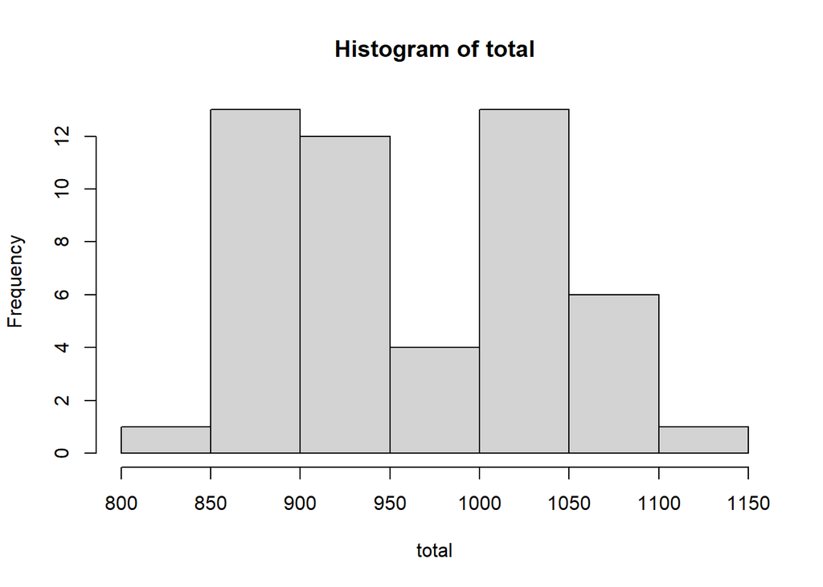

```r
# help(sat)
data(sat)
str(sat); head(sat); hist(sat$total, main = "Histogram of total", xlab = "total")
```

### Problem 2a

Fit a model with `total` (Y) sat score as the response and `takers` $(X_1)$, `ratio` $(X_2)$, and `salary` $(X_3)$ as predictors. Comment on the goodness of fit.

According to the (adj)-$R^2$ value, approximately 81.24% of the variability in `total` can be explained by the association with its predictors under the fitted model. This indicates a strong relationship between the chosen predictors and SAT performance, though other unmeasured factors still contribute to the remaining unexplained variation.

The RMSE ($\hat{\sigma}$) of 32.41 means that, after accounting for the effects of the proportion of test takers, student–teacher ratio, and teacher salary, the model predicts state average SAT total scores with a typical error of about 32 points.

```r
fit2 <- lm(total ~ takers + ratio + salary, sat)
summary(fit2)
```

```
##
## Call:
## lm(formula = total ~ takers + ratio + salary, data = sat)
##
## Residuals:
##     Min      1Q  Median      3Q     Max
## -89.244 -21.485  -0.798  17.685  68.262
##
## Coefficients:
##              Estimate Std. Error t value Pr(>|t|)
## (Intercept) 1057.8982    44.3287  23.865   <2e-16 ***
## takers        -2.9134     0.2282 -12.764   <2e-16 ***
## ratio         -4.6394     2.1215  -2.187   0.0339 *
## salary         2.5525     1.0045   2.541   0.0145 *
## ---
## Signif. codes:  0 '***' 0.001 '**' 0.01 '*' 0.05 '.' 0.1 ' ' 1
##
## Residual standard error: 32.41 on 46 degrees of freedom
## Multiple R-squared:  0.8239, Adjusted R-squared:  0.8124
## F-statistic: 71.72 on 3 and 46 DF,  p-value: < 2.2e-16
```

### Problem 2b

Using the R output from (a), test the hypothesis that the variable `ratio` (average pupil/teacher ratio) has an effect on the SAT scores. Specify $H_0$ and $H_A$, the test statistic value, p-value, and your conclusion.

This problem is expressed by the following:

$$H_o: \beta_{ratio} = 0 \text{ versus }
H_a:\beta_{ratio} \ne 0$$

The test statistic is given by $t_{46} \approx -2.19$. The two-sided p-value is $P(|t_{46}| \ge 2.19) \approx 0.034$ This means that, under the null hypothesis $H_0: \beta_{\text{ratio}} = 0$, observing a test statistic as (or more) extreme than $t_{46} = -2.19$ is unlikely. Since $p = 0.034 \lt \alpha = 0.05$, we reject $H_0$. In other words, the data provide evidence for a (nonzero) linear effect of `ratio` on `total`.

```r
cat("----------- Testing ratio Coefficient -----------\n")
```

```
## ----------- Testing ratio Coefficient -----------
```

```r
summary(fit2)$coefficients["ratio",]
```

```
##    Estimate  Std. Error     t value    Pr(>|t|)
## -4.63942805  2.12151421 -2.18684750  0.03387652
```

### Problem 2c

For the model in (a), what would be the $H_0$ and $H_A$ if you wish to claim that a higher value of `ratio` tends to lead to a lower sat score. What would be the numerical value of the test statistics, p-value, and conclusion for your test?

This problem is expressed by the following:

$$H_o: \beta_{ratio} = 0 \text{ versus }
H_a:\beta_{ratio} \lt 0$$

The test statistic is given by $t_{46} = -2.19$. The one-sided p-value is $P(t_{46} \lt -2.19) \approx 0.017$ This means that, under the null hypothesis $H_0: \beta_{\text{ratio}} = 0$, observing a test statistic less than $t_{46} = -2.19$ is unlikely. Since $p = 0.017 \lt \alpha = 0.05$, we reject $H_0$. In other words, the data provide evidence that a higher value of `ratio` tends to lead to a lower `sat` score.

```r
cat("----------- Testing one-sided (lower-tail) Ratio Coef -----------\n")
```

```
## ----------- Testing one-sided (lower-tail) Ratio Coef -----------
```

```r
t.val <- summary(fit2)$coefficients["ratio","t value"]
pt(t.val, df = 46, lower.tail = T)
```

```
## [1] 0.01693826
```

### Problem 2d

For the model in (a), test the hypothesis $\beta_{takers} = \beta_{ratio} = \beta_{salary} = 0.$ Explain in words what this hypothesis means. Specify the test statistic value, p-value, and your conclusion.

The test statistic is given by $F_{3,46} \approx 71.72$. The p-value is $P(F_{3,46} > 71.72) \approx 2.26*10^{-17}$ This means that, under the null hypothesis $H_o: \beta_{takers} = \beta_{ratio} = \beta_{salary} = 0$, observing a test statistic as (or more) extreme than $F_{3,46} = 71.72$ is extremely unlikely. Since $p \ll \alpha = 0.05$, we reject $H_0$. In other words, there is evidence to suggest at least one of the predictors from the previous model (in a) has a significant (linear) effect on `total`.

```r
cat("---------- F-Statistic (and df) ---------\n")
```

```
## ---------- F-Statistic (and df) ---------
```

```r
f.stat <- summary(fit2)$fstatistic
print(f.stat)
```

```
##    value    numdf    dendf
## 71.72077  3.00000 46.00000
```

```r
cat("---------- p-value ------------\n")
```

```
## ---------- p-value ------------
```

```r
pf(71.72, df1 = 3, df2 = 46, lower.tail = F)
```

```
## [1] 2.263212e-17
```

### Problem 2e

Now add `expend` $(X_4)$ (current expenditure per pupil) to the model and fit it. Comment on the estimated regression coefficients of `takers`, `ratio`, and `salary`, their significance and the goodness of fit as compared to the results form the model in question (a).

The regression coefficients for predictors in both model (a) and (e) are the same sign but different values. See the summary table below to observe how each of these coefficients shrink or tend closer to 0 after adding `expend` to the new model in (e).

The RMSE ($\hat{\sigma}$) changed from 32.41 to 32.7, i.e. a typical error in `total` slightly increases with the inclusion of the `expend` variable.

```r
cat("---------- (Linear) Model: total = takers + ratio + salary -----------\n")
```

```
## ---------- (Linear) Model: total = takers + ratio + salary -----------
```

```r
coefs2 <- summary(fit2)$coefficients; print(coefs2)
```

```
##                Estimate Std. Error    t value     Pr(>|t|)
## (Intercept) 1057.898162 44.3286685  23.864876 1.496236e-27
## takers        -2.913350  0.2282436 -12.764215 1.007685e-16
## ratio         -4.639428  2.1215142  -2.186847 3.387652e-02
## salary         2.552470  1.0045183   2.540989 1.449126e-02
```

```r
cat("\n---------- (Linear) Model: total = takers + ratio + salary + expend -----\n")
```

```
##
## ---------- (Linear) Model: total = takers + ratio + salary + expend -----
```

```r
fit3 <- lm(total ~ takers + ratio + salary + expend, sat)
summary(fit3)
```

```
##
## Call:
## lm(formula = total ~ takers + ratio + salary + expend, data = sat)
##
## Residuals:
##     Min      1Q  Median      3Q     Max
## -90.531 -20.855  -1.746  15.979  66.571
##
## Coefficients:
##              Estimate Std. Error t value Pr(>|t|)
## (Intercept) 1045.9715    52.8698  19.784  < 2e-16 ***
## takers        -2.9045     0.2313 -12.559 2.61e-16 ***
## ratio         -3.6242     3.2154  -1.127    0.266
## salary         1.6379     2.3872   0.686    0.496
## expend         4.4626    10.5465   0.423    0.674
## ---
## Signif. codes:  0 '***' 0.001 '**' 0.01 '*' 0.05 '.' 0.1 ' ' 1
##
## Residual standard error: 32.7 on 45 degrees of freedom
## Multiple R-squared:  0.8246, Adjusted R-squared:  0.809
## F-statistic: 52.88 on 4 and 45 DF,  p-value: < 2.2e-16
```

### Problem 2f

Under the model of question (e), test the hypothesis $\beta_{takers} = \beta_{ratio} = \beta_{salary} = 0$ and show your test results. Based on your entire analysis, do you feel any of these predictors have an effect on the response?

The test statistic is given by $F_{3,45} \approx 58.12$. The p-value is $P(F_{3,45} > 58.12) = 1.62*10^{-15}$ This means that, under the null hypothesis $H_o: \beta_{takers} = \beta_{ratio} = \beta_{salary} = 0$, observing a test statistic as (or more) extreme than $F_{3,45} = 58.12$ is extremely unlikely. Since $p \ll \alpha = 0.05$, we reject $H_0$. In other words, there is evidence to suggest at least one of the predictors: `takers`, `ratio`, and/or `salary` have a significant (linear) effect on `total`.

```r
h0 <- lm(total ~ expend, sat)
# fit3 <- lm(total ~ takers + ratio + salary + expend, sat)
anova(h0, fit3)
```

```
## Analysis of Variance Table
##
## Model 1: total ~ expend
## Model 2: total ~ takers + ratio + salary + expend
##   Res.Df    RSS Df Sum of Sq      F   Pr(>F)
## 1     48 234586
## 2     45  48124  3    186462 58.119 1.62e-15 ***
## ---
## Signif. codes:  0 '***' 0.001 '**' 0.01 '*' 0.05 '.' 0.1 ' ' 1
```